# The Effect of Dose and Delivery Method of Vitamin C on the Growth of Odontoblasts of the Incisor Tooth of the Guinea Pig

John James

March 28, 2016

# Introduction

**Objectives:** The purpose of the study was to ascertain the degree to which delivery method and/or dosage affect growth of odontoblast cells in guinea pigs.

**Conclusions:** There is a positive correlation between vitamin C dose and incisor odontoblast cell growth in guinea pigs, regardless of delivery method. Further, greater cell growth is associated with the administration of vitamin C with orange juice, at the lower doses (0.5mg and 1mg). There is no statistically significant difference in cell growth between delivery methods at the 2mg dose.

# Data

## Summary

The data frame consisted of 60 observations on 3 variables.

1. Length - The length of the odontoblast cell in microns[3]
2. Supplement - The delivery method, eith er orange Juice or an aqueous solution of ascorbic acid
3. Dose - Dose in milligrams per day. Values were 0.5, 1.0, and 2.0.

To facilitate data analysis, the data frame was copied and the dose was changed to a factor variable and the dose and supp variables were combined to create a third combined variable.

As shown in Table 1, there were 60 total observations and the data approximates N(μ = 18.81, σ<sup>2</sup> = 58.51). There were 0 NA values observed in the data.

## Data Distribution

Figure 3 evinces an approximately normal, albiet slightly left skewed, distribution of the observations for all doses and, with the exception of a spike in measurements at about 9 microns, for treatments where vitamin C was administered with orange juice. Measurements for the 0.5 and 2mg doses, as well as for those in which vitamin C was administered with the aqueous solution, are slightly right skewed normal. The distribution of measurements for the 1mg dose are bimodal and nearly symmetrical.

# Methods

# Key Assumptions

# Analysis

## Impact of Vitamin C Dose on Odontoblast Cell Growth

To ascertain the statistical difference in mean cell growth among the doses, the following hypotheses were tested.

**1mg versus 0.5mg Dose**  
H0: μ1 = μ0 where μ0 is mean cell growth for 0.5mg Ha: μ1 <> μ0 μ1 is mean cell growth for 1mg

The difference in mean growth rates,9.13, was within The 95% confidence interval, [6.39,11.87]. Since the confidence interval doesn’t contain zeroa and the p.value, 1.225436710^{-6}, is substantially below α = 0.5, the null hypothesis is rejected. As such, 1mg dose produced statistically greater cell growth than the 0.5mg dose.

**2mg versus 1mg Dose**  
H0: μ2 = μ1 where μ1 is mean cell growth for 1mg Ha: μ2 <> μ1 μ2 is mean cell growth for 2mg

Similarly, the difference in mean cell growth between the 1mg and 2mg doses, 6.365, was well within the 95% confidence interval, [3.47,9.26]. The p.value, 1.93418610^{-4}, is substantially below α = 0.5 and the 95% confidence interval does not contain zero. Therefore, the null hypothesis is rejected.

## Impact of Vitamin C Delivery Method on Odontoblast Cell Growth

To obtain the statistical difference in mean cell growth between the two delivery methods, the following hypothesis was tested. H0: μ1 = μ0 where μ0 is mean cell growth for OJ Ha: μ1 <> μ0 μ1 is mean cell growth for VC

## Impact of Treatment (Dose/Delivery) on Odontoblast Cell Growth

The following top-three performing treatments were tested.

- Treatment 1: 1 milligram dose of Vitamin C with orange juice
- Treatment 2: 2 milligram dose of Vitamin C with orange juice
- Treatment 3: 2 milligram dose of Vitamin C with the aqueous solution of ascorbic acid

### Treatment 1 versus Treatment 2

The following hypotheses were tested.

H0: μ1 = μ2 where μ1 is mean cell growth for Treatment 1 Ha: μ1 <> μ2 μ2 is mean cell growth for Treatment 2

The difference in means, 3.36, was within the 95% confidence interval, [-0.55,7.27], which included zero difference between the means. Further, the p.value, 0.0838391, was in excess of α = 0.05, Therefore, the null hypothesis was not rejected. Ergo, there is no statistically significant difference between these two treatments.

### Treatment 2 versus Treatment 3

The following hypotheses were tested. H0: μ2 = μ3 where μ2 is mean cell growth for Treatment 2 Ha: μ2 <> μ3 μ3 is mean cell growth for Treatment 3

The difference in means, 0.08, is within the 95% confidence interval, [-4.17,4.33], which includes zero difference between the means. Further, the p.value, 0.9669567, exceeds α = 0.05. Therefore, the null hypothesis was not rejected. As such, there is no significant difference in cell growth between these treatments.

### Treatment 1 versus Treatment 3

The following hypotheses were tested. H0: μ1 = μ3 where μ1 is mean cell growth for Treatment 1 Ha: μ1 <> μ3 μ3 is mean cell growth for Treatment 3

The difference in means, 3.44, was within the 95% confidence interval, [0.03,6.85], which did not include zero. Further, the p.value, 0.0482836, was *slightly* less than α = 0.05. Therefore, the null hypothesis was rejected. As such, the analysis shows that there is a statistically significant difference in growth rates between these two treatments.

# Conclusions

The analysis shows statistically different mean odontoblast cell growth at each **dose** level. Higher doses directly correlate with greater cell growth, regardless of delivery method.

# References

1. Crampton, E. W. (1947). The growth of the odontoblast of the incisor teeth as a criterion of vitamin C intake of the guinea pig. The Journal of Nutrition, 33(5): 491–504.
2. Maechler, M. (n.d.). R Manual. Retrieved from R Manual: https://stat.ethz.ch/R-manual/R-devel/library/datasets/html/ToothGrowth.html
3. Kuns, E. (2015, April 17). Bug 15953 - ToothGrowth {datasets} description improvement. Retrieved from Bugzilla: https://bugs.r-project.org/bugzilla3/show_bug.cgi?id=15953
4. Winter, J. d. (2013). Using the Student’s t-test with extremely small sample sizes. Practical Assessment, Research & Evaluation.

# Appendix

## Figures

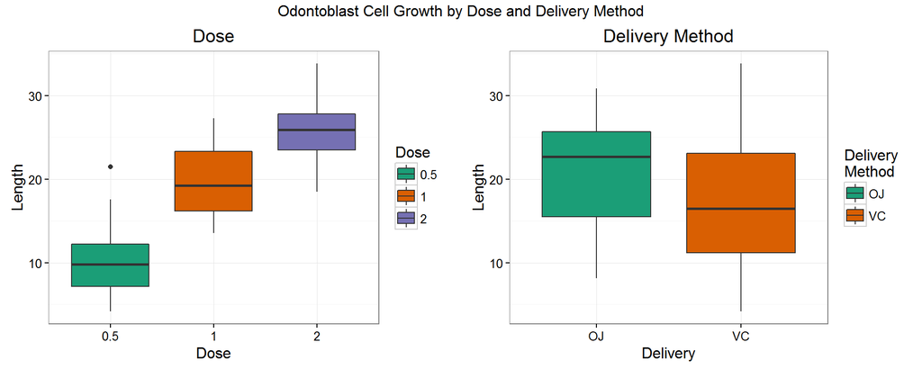

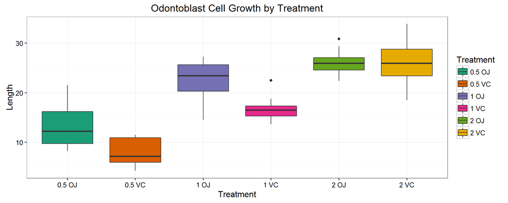

Figure 1: Odontoblast Cell Growth by Dose, Delivery & Treatment

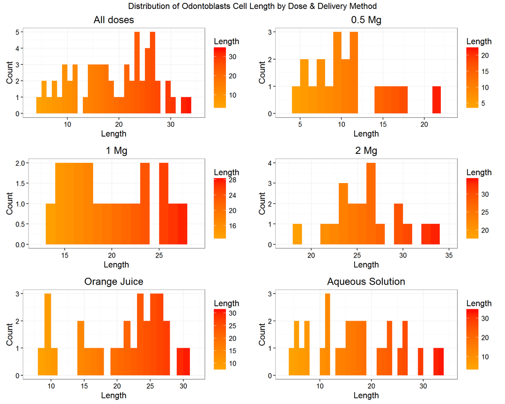

Figure 3: Distributions of Odontoblasts Cell Growth

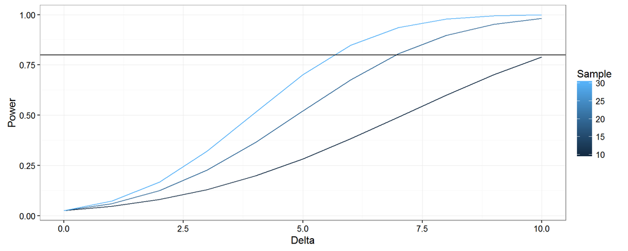

Figure 4: Power Curve

## Tables

Table 1: Descriptive Statistics of Tooth Growth Data Set

|  | n | NAs | Min | Max | Median | Mean | Var | Std Dev |
| --- | --- | --- | --- | --- | --- | --- | --- | --- |
| Tooth Growth Data | 60 | 0 | 4.2 | 33.9 | 19.25 | 18.81333 | 58.51202 | 7.649315 |

Table 2: Descriptive Statistics of Tooth Growth Data Set by Dose

|  | n | NAs | Min | Max | Median | Mean | Var | Std Dev |
| --- | --- | --- | --- | --- | --- | --- | --- | --- |
| 0.5mg | 20 | 0 | 4.2 | 21.5 | 9.85 | 10.605 | 20.24787 | 4.499763 |
| 1mg | 20 | 0 | 13.6 | 27.3 | 19.25 | 19.735 | 19.49608 | 4.415436 |
| 2mg | 20 | 0 | 18.5 | 33.9 | 25.95 | 26.100 | 14.24421 | 3.774150 |

Table 3: Descriptive Statistics of Tooth Growth Data Set by Delivery Method

|  | n | NAs | Min | Max | Median | Mean | Var | Std Dev |
| --- | --- | --- | --- | --- | --- | --- | --- | --- |
| OJ | 30 | 0 | 8.2 | 30.9 | 22.7 | 20.66333 | 43.63344 | 6.605561 |
| Sol | 30 | 0 | 4.2 | 33.9 | 16.5 | 16.96333 | 68.32723 | 8.266029 |

Table 4: Descriptive Statistics of Tooth Growth Data Set by Treatment

|  | n | NAs | Min | Max | Median | Mean | Var | Std Dev |
| --- | --- | --- | --- | --- | --- | --- | --- | --- |
| Treatment 0: 0.5mg with Orange Juice | 10 | 0 | 8.2 | 21.5 | 12.25 | 13.23 | 19.889000 | 4.459708 |
| Treatment 1: 0.5mg with Aqueous Solution | 10 | 0 | 4.2 | 11.5 | 7.15 | 7.98 | 7.544000 | 2.746634 |
| Treatment 2: 1mg with Orange Juice | 10 | 0 | 14.5 | 27.3 | 23.45 | 22.70 | 15.295556 | 3.910953 |
| Treatment 3: 1mg with Aqueous Solution | 10 | 0 | 13.6 | 22.5 | 16.50 | 16.77 | 6.326778 | 2.515309 |
| Treatment 4: 2mg with Orange Juice | 10 | 0 | 22.4 | 30.9 | 25.95 | 26.06 | 7.049333 | 2.655058 |
| Treatment 5: 2mg with Aqueous Solution | 10 | 0 | 18.5 | 33.9 | 25.95 | 26.14 | 23.018222 | 4.797731 |

## Code

**Calculate Descriptive Statistics

```r
## Column indexes and names
colIndex <- c(1, 3:5, 8:9, 12:13)
colNames <- c("n", "NAs", "Min", "Max", "Median", "Mean", "Var", "Std Dev")

## Overall Stats
tgStats <- tg$len
tgStats <- data.frame(stat.desc(tgStats))
colnames(tgStats) <- "Tooth Growth Data"
tgStats <- data.frame(t(tgStats))
tgStats <- tgStats[, colIndex]
colnames(tgStats) <- colNames


## Stats by Dose
dose0 <- subset(tg, dose == "0.5")$len
dose1 <- subset(tg, dose == "1")$len
dose2 <- subset(tg, dose == "2")$len
doses <- cbind(dose0, dose1, dose2)
doseStats <- stat.desc(doses)
colnames(doseStats) <- c("0.5mg", "1mg", "2mg")
doseStats <- t(doseStats)
doseStats <- doseStats[, colIndex]
colnames(doseStats) <- colNames

## Stats by Supp
supp0 <- subset(tg, supp == "OJ")$len
supp1 <- subset(tg, supp == "VC")$len
suppStats <- cbind(supp0, supp1)
suppStats <- stat.desc(suppStats)
colnames(suppStats) <- c("OJ", "Sol")
suppStats <- t(suppStats)
suppStats <- suppStats[, colIndex]
colnames(suppStats) <- colNames


## Stats by Treatment
treatment0 <- subset(tg, dose.supp == "0.5 OJ")$len
treatment1 <- subset(tg, dose.supp == "0.5 VC")$len
treatment2 <- subset(tg, dose.supp == "1 OJ")$len
treatment3 <- subset(tg, dose.supp == "1 VC")$len
treatment4 <- subset(tg, dose.supp == "2 OJ")$len
treatment5 <- subset(tg, dose.supp == "2 VC")$len
treatmentStats <- cbind(treatment0, treatment1, treatment2, treatment3, treatment4,
    treatment5)
treatmentStats <- stat.desc(treatmentStats)
colnames(treatmentStats) <- c("Treatment 0: 0.5mg with Orange Juice", "Treatment 1: 0.5mg with Aqueous Solution",
    "Treatment 2: 1mg with Orange Juice", "Treatment 3: 1mg with Aqueous Solution",
    "Treatment 4: 2mg with Orange Juice", "Treatment 5: 2mg with Aqueous Solution")
treatmentStats <- t(treatmentStats)
treatmentStats <- treatmentStats[, colIndex]
colnames(treatmentStats) <- colNames
```

**Conduct t-tests***

```r
## Difference in mean cell growth between doses
doseResults <- list()
doseResults[[1]] <- t.test(tg$len[tg$dose == "1"] - tg$len[tg$dose == "0.5"])
doseResults[[2]] <- t.test(tg$len[tg$dose == "2"] - tg$len[tg$dose == "1"])

## Difference in mean cell growth between delivery methods
suppResults <- list()
suppResults[[1]] <- t.test(tg$len[tg$supp == "OJ"] - tg$len[tg$supp == "VC"])

## Difference in mean cell growth between treatments
treatmentResults <- list()
treatmentResults[[1]] <- t.test(tg$len[tg$dose.supp == "2 OJ"] - tg$len[tg$dose.supp ==
    "1 OJ"])
treatmentResults[[2]] <- t.test(tg$len[tg$dose.supp == "2 VC"] - tg$len[tg$dose.supp ==
    "2 OJ"])
treatmentResults[[3]] <- t.test(tg$len[tg$dose.supp == "2 VC"] - tg$len[tg$dose.supp ==
    "1 OJ"])

## Store Results
doseTest <- t(sapply(doseResults, function(x) {
    c(x$estimate, ci = x$conf.int, pv = x$p.value)
}))
suppTest <- t(sapply(suppResults, function(x) {
    c(x$estimate, ci = x$conf.int, pv = x$p.value)
}))

treatmentTest <- t(sapply(treatmentResults, function(x) {
    c(x$estimate, ci = x$conf.int, pv = x$p.value)
}))
```

```r
anchors("index")
```

| label | type | number |
| --- | --- | --- |
| tgStats | Table | 1 |
| boxPlots | Figure | 1 |
| doseStats | Table | 2 |
| suppStats | Table | 3 |
| treatmentBoxPlot | Figure | 2 |
| treatmentStats | Table | 4 |
| distributions | Figure | 3 |
| powerCurve | Figure | 4 |